# Have I converged

## Scatter plots

Extract the parameters of the fit and plot them

```r
params=extract(fit, permuted=FALSE, inc_warmup=TRUE)
```

```r
plot(c(-5,25), c(-5,25), ty='n', xlab='mu', ylab='tau')
lines(params[,'chain:1','mu'], params[,'chain:1','tau'], col='black',ty='o', pch=20)
```

```r
lines(params[,'chain:2','mu'], params[,'chain:2','tau'], col='orange',ty='o', pch=20)
lines(params[,'chain:3','mu'], params[,'chain:3','tau'], col='red',ty='o', pch=20)
```

[figure not shown]

```r
lines(params[,'chain:4','mu'], params[,'chain:4','tau'], col='gray',ty='o', pch=20)
legend('topright', legend=c('chain1', 'chain2', 'chain3', 'chain4'), col=c('black', 'orange', 'red', 'gray'), lty='solid', bty='n')
```

## Trace plots

From the scatter plot and the trace plots, we can see that the chains are not well mixed. Their distributions are very different.

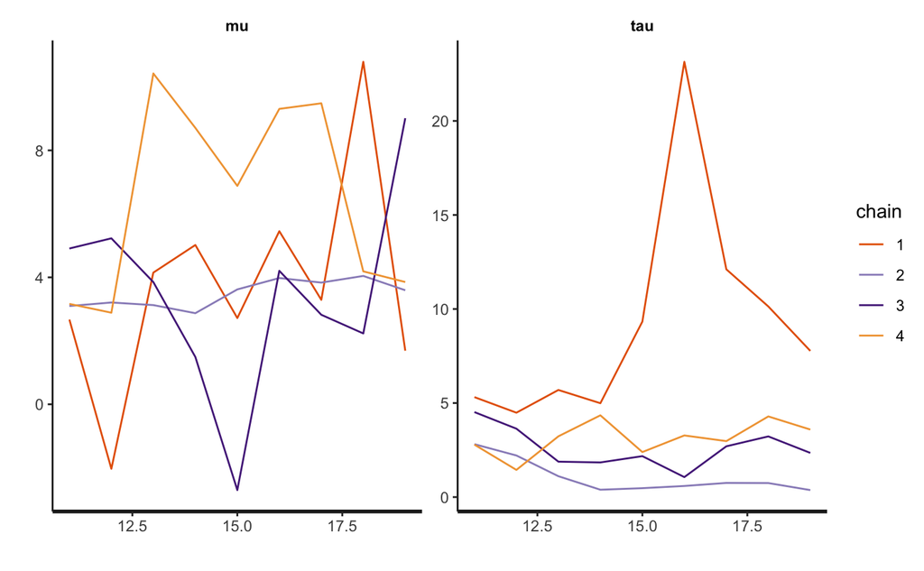

```r
traceplot(fit, pars=c('mu','tau'))
```

By increasing the number of iterations, and throwing away the warmup we can improve the mixing.

```r
fit = stan(model_code = schools_code, data=schools_dat, chains = 4,iter = 1000)
```

```
There were 41 divergent transitions after warmup. Increasing adapt_delta above 0.8 may help. See
http://mc-stan.org/misc/warnings.html#divergent-transitions-after-warmupExamine the pairs() plot to diagnose sampling problems
Bulk Effective Samples Size (ESS) is too low, indicating posterior means and medians may be unreliable.
Running the chains for more iterations may help. See
http://mc-stan.org/misc/warnings.html#bulk-essTail Effective Samples Size (ESS) is too low, indicating posterior variances and tail quantiles may be unreliable.
Running the chains for more iterations may help. See
http://mc-stan.org/misc/warnings.html#tail-ess
```

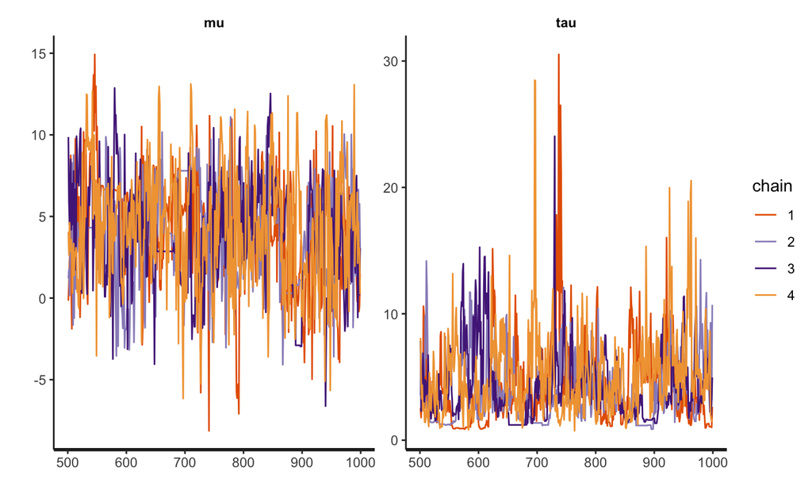

```r
traceplot(fit, pars=c('mu','tau'))
```

## Rhat

Rhat statistic is given in the last column of the print() function. It compares the variances of the pooled chains to the individual chains for each parameter. Ideally Rhat should be less than 1.1

```r
print(fit)
```

```
Inference for Stan model: e95dbc42841983babc674429f4062b71.
4 chains, each with iter=1000; warmup=500; thin=1;
post-warmup draws per chain=500, total post-warmup draws=2000.

           mean se_mean   sd   2.5%    25%    50%    75% 97.5% n_eff Rhat
mu         3.97    0.22 3.28  -2.70   1.66   4.08   6.33 10.23   224 1.02
tau        4.38    0.26 3.10   1.04   2.17   3.65   5.77 11.77   137 1.01
theta[1]   6.13    0.27 5.60  -3.68   2.59   5.60   9.34 18.66   418 1.01
theta[2]   4.79    0.22 4.91  -4.69   1.68   4.70   7.69 14.92   493 1.01
theta[3]   3.41    0.24 5.64  -8.28   0.11   3.66   6.84 14.19   538 1.01
theta[4]   4.40    0.23 5.15  -5.76   1.36   4.35   7.45 15.21   515 1.01
theta[5]   3.02    0.23 4.86  -7.72   0.28   3.11   6.38 11.65   447 1.01
theta[6]   3.57    0.23 5.25  -7.50   0.60   3.88   6.74 13.54   532 1.01
theta[7]   6.46    0.28 5.21  -2.17   2.89   5.99   9.14 18.63   357 1.01
theta[8]   4.61    0.21 5.63  -6.02   1.17   4.63   7.76 16.18   723 1.01
lp__     -16.58    0.58 5.29 -26.27 -20.47 -16.79 -12.90 -6.34    84 1.03

Samples were drawn using NUTS(diag_e) at Sun Jun  7 10:08:26 2020.
For each parameter, n_eff is a crude measure of effective sample size,
and Rhat is the potential scale reduction factor on split chains (at
convergence, Rhat=1).
```

## Neff

Neff is the number of effective samples, it tells you the number of samples taking into account the correlations between samples. Ideally the number of effective samples divided by the number of iterations should be greater than 0.01

```r
neff = summary(fit)$summary[,'n_eff']
neff/4000
```

```
        mu        tau   theta[1]   theta[2]   theta[3]   theta[4]   theta[5]
0.05608877 0.03428766 0.10461623 0.12324362 0.13451459 0.12881906 0.11183183
  theta[6]   theta[7]   theta[8]       lp__
0.13306915 0.08924116 0.18082072 0.02090260
```

Sometimes the number of effective samples can be different in the bulk of the posterior compared to in the tails. Its useful to check these values too with the monitor() function. The bulk_ESS and tail_ESS should be greater than 100 per chain.

```r
monitor(extract(fit, permuted = FALSE, inc_warmup = FALSE))
```

```
Inference for the input samples (4 chains: each with iter = 500; warmup = 250):
```

|  | Q5 | Q50 | Q95 | Mean | SD | Rhat | Bulk_ESS | Tail_ESS |
| --- | --- | --- | --- | --- | --- | --- | --- | --- |
| mu | -1.8 | 3.6 | 8.9 | 3.5 | 3.3 | 1.04 | 160 | 274 |
| tau | 1.2 | 3.9 | 9.6 | 4.5 | 2.8 | 1.04 | 67 | 61 |
| theta[1] | -2.9 | 5.3 | 15.2 | 5.7 | 5.8 | 1.02 | 291 | 451 |
| theta[2] | -3.7 | 4.2 | 12.7 | 4.3 | 5.1 | 1.01 | 371 | 626 |
| theta[3] | -6.6 | 3.1 | 11.6 | 2.9 | 5.6 | 1.01 | 388 | 691 |
| theta[4] | -4.8 | 3.9 | 12.4 | 3.8 | 5.3 | 1.02 | 408 | 511 |
| theta[5] | -5.6 | 2.8 | 10.5 | 2.7 | 5.0 | 1.01 | 337 | 533 |
| theta[6] | -5.5 | 3.2 | 12.0 | 3.1 | 5.2 | 1.02 | 338 | 381 |
| theta[7] | -1.5 | 5.8 | 15.5 | 6.1 | 5.2 | 1.02 | 246 | 399 |
| theta[8] | -4.3 | 4.0 | 13.2 | 4.2 | 5.4 | 1.01 | 396 | 668 |

[output cut: 1 more lines]

```
For each parameter, Bulk_ESS and Tail_ESS are crude measures of
effective sample size for bulk and tail quantities respectively (an ESS > 100
per chain is considered good), and Rhat is the potential scale reduction
factor on rank normalized split chains (at convergence, Rhat <= 1.05).
```

Running larger chains and thinning the chains can sometimes help improve the effective sample size.

```r
fit = stan(model_code = schools_code, data=schools_dat, chains = 4,iter = 10000, warmup = 500)
```

```
There were 668 divergent transitions after warmup. Increasing adapt_delta above 0.8 may help. See
http://mc-stan.org/misc/warnings.html#divergent-transitions-after-warmupThere were 1 chains where the estimated Bayesian Fraction of Missing Information was low. See
http://mc-stan.org/misc/warnings.html#bfmi-lowExamine the pairs() plot to diagnose sampling problems
```

## Divergences

Divergences are indicators of regions of high curvature that is not well explored by Stan. These can be seen as red points in the pairs() plot of parameters.

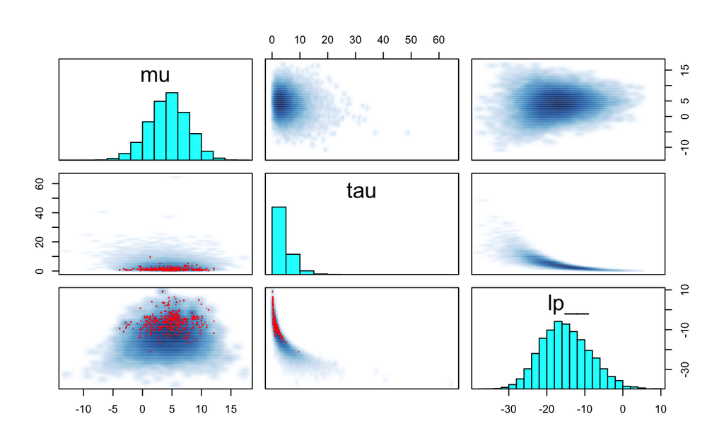

```r
pairs(fit, pars=c('mu', 'tau','lp__'))
```

Increasing adapt_delta can sometimes reduce the number of divergences

```r
adapt_delta = c(0.8, 0.85, 0.9, 0.95)
ndiv = get_num_divergent(fit)

for(i in 2:4){
  fit = stan(model_code = schools_code, data=schools_dat, chains = 4,iter = 10000, warmup = 500,control=list(adapt_delta=adapt_delta[i]))
  ndiv = c(ndiv,get_num_divergent(fit))
}
```

```
There were 804 divergent transitions after warmup. Increasing adapt_delta above 0.85 may help. See
http://mc-stan.org/misc/warnings.html#divergent-transitions-after-warmupThere were 1 chains where the estimated Bayesian Fraction of Missing Information was low. See
http://mc-stan.org/misc/warnings.html#bfmi-lowExamine the pairs() plot to diagnose sampling problems
```

```
There were 1835 divergent transitions after warmup. Increasing adapt_delta above 0.9 may help. See
http://mc-stan.org/misc/warnings.html#divergent-transitions-after-warmupThere were 1 chains where the estimated Bayesian Fraction of Missing Information was low. See
http://mc-stan.org/misc/warnings.html#bfmi-lowExamine the pairs() plot to diagnose sampling problems
The largest R-hat is 1.06, indicating chains have not mixed.
Running the chains for more iterations may help. See
http://mc-stan.org/misc/warnings.html#r-hatBulk Effective Samples Size (ESS) is too low, indicating posterior means and medians may be unreliable.
Running the chains for more iterations may help. See
http://mc-stan.org/misc/warnings.html#bulk-essTail Effective Samples Size (ESS) is too low, indicating posterior variances and tail quantiles may be unreliable.
Running the chains for more iterations may help. See
http://mc-stan.org/misc/warnings.html#tail-ess
```

```
There were 794 divergent transitions after warmup. Increasing adapt_delta above 0.95 may help. See
http://mc-stan.org/misc/warnings.html#divergent-transitions-after-warmupThere were 1 chains where the estimated Bayesian Fraction of Missing Information was low. See
http://mc-stan.org/misc/warnings.html#bfmi-lowExamine the pairs() plot to diagnose sampling problems
Tail Effective Samples Size (ESS) is too low, indicating posterior variances and tail quantiles may be unreliable.
Running the chains for more iterations may help. See
http://mc-stan.org/misc/warnings.html#tail-ess
```

However if the number of divergences does not decrease with increase of adapt delta, then your model requires reparameterisation.

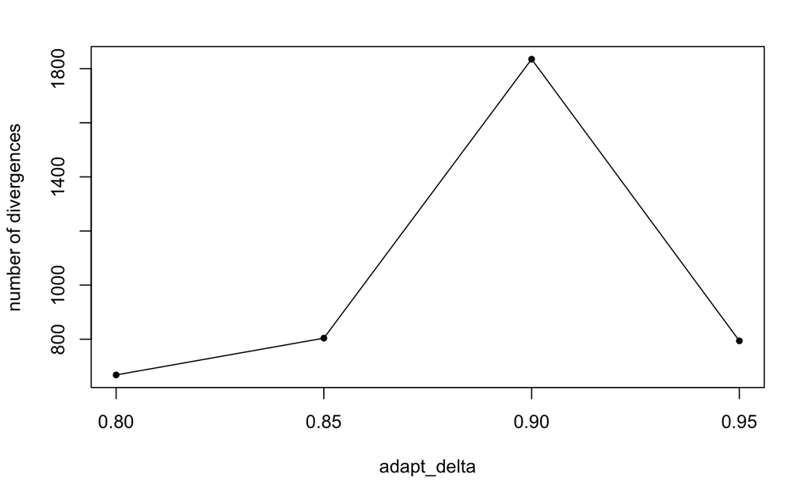

```r
plot(adapt_delta,ndiv, ty='o', pch=20, xlab='adapt_delta', ylab='number of divergences')
```

```r
schools_code = "
data {
    int<lower=0> J; // number of schools
    vector[J] y; // observed treatment effect
    vector<lower=0>[J] sigma; // uncertainty on observed effect
}

parameters {
    real mu; // population treatment effect
    real<lower=0> tau; //population scale
    vector[J] eta;  //unscaled deviation from mu by school
}

transformed parameters {
    vector[J] theta; // true treatment effect

    theta = mu + tau * eta;
}

model {
  //(hyper) priors
    mu ~ normal(0,5);
    tau ~ cauchy(0,5);
    eta ~ normal(0,1);

  //likelihood
    y ~ normal(theta, sigma);
}
"
```

```r
fit = stan(model_code = schools_code, data=schools_dat, chains = 4,iter = 10000, warmup = 500, control = list(adapt_delta=0.95))
```

```
recompiling to avoid crashing R session
```

```r
print(fit)
```

```
Inference for Stan model: fa2ddb7bce74a1603ce0d61f26ae597d.
4 chains, each with iter=10000; warmup=500; thin=1;
post-warmup draws per chain=9500, total post-warmup draws=38000.

          mean se_mean   sd   2.5%   25%   50%   75% 97.5% n_eff Rhat
mu        4.41    0.02 3.30  -2.09  2.18  4.43  6.64 10.83 45983    1
tau       3.62    0.02 3.24   0.12  1.26  2.77  5.02 11.85 30439    1
eta[1]    0.32    0.00 0.98  -1.63 -0.33  0.33  0.99  2.23 48054    1
eta[2]    0.09    0.00 0.93  -1.77 -0.52  0.10  0.72  1.89 56930    1
eta[3]   -0.08    0.00 0.97  -1.98 -0.73 -0.08  0.56  1.82 58319    1
eta[4]    0.06    0.00 0.95  -1.82 -0.57  0.07  0.69  1.91 49188    1
eta[5]   -0.16    0.00 0.93  -1.97 -0.79 -0.17  0.45  1.68 55740    1
eta[6]   -0.07    0.00 0.95  -1.92 -0.71 -0.07  0.56  1.80 56049    1
eta[7]    0.35    0.00 0.95  -1.58 -0.28  0.37  1.00  2.16 44821    1
eta[8]    0.08    0.00 0.98  -1.86 -0.58  0.08  0.74  1.99 55506    1
theta[1]  6.25    0.03 5.63  -3.09  2.74  5.66  8.98 19.76 41221    1
theta[2]  4.95    0.02 4.68  -4.02  2.02  4.83  7.75 14.69 49772    1
theta[3]  3.92    0.03 5.25  -7.59  1.06  4.16  7.11 13.71 42835    1
theta[4]  4.75    0.02 4.75  -4.55  1.84  4.70  7.57 14.42 45882    1
theta[5]  3.59    0.02 4.65  -6.59  0.91  3.81  6.60 12.13 48409    1
theta[6]  4.04    0.02 4.85  -6.32  1.25  4.19  7.06 13.18 47868    1
theta[7]  6.27    0.02 5.08  -2.38  2.97  5.78  8.96 18.18 44505    1
theta[8]  4.85    0.03 5.36  -5.83  1.79  4.76  7.80 16.12 44216    1
lp__     -6.93    0.02 2.33 -12.31 -8.29 -6.62 -5.23 -3.31 14909    1

Samples were drawn using NUTS(diag_e) at Sun Jun  7 12:45:42 2020.
For each parameter, n_eff is a crude measure of effective sample size,
and Rhat is the potential scale reduction factor on split chains (at
convergence, Rhat=1).
```